# Machine_Learning

What we need to be certain about in terms of the Revolut's goal and mission is that customer engagement and satisfaction is key. There are 4 tables that depict the users' attributes and their behaviour on the Revolut app.

- Devices of the users noting the brand of phone being used.
- users attributes which tells us more about attributes of each user and how which plan they are subscribed to.
- Notifications entail the characteristics of the notifications they recieve on the app.
- transactions gives us an inisght into how they use the app to manage their finances and make/recieve certain different kinds of payments/transfers.

The target metric chosen to measure user engagement on the Revolut app is the number of transactions each user has on the app. An engaged user would have lots of transactions on the platform and an unengaged user would have barely an transactions on the platform.

# LOADING THE CSV FILES AND LIBRARIES

```python
#load the data and import the necessary libraries
%load_ext autoreload
%autoreload 2
import numpy as np
import pandas as pd
import seaborn as sns
import matplotlib.pyplot as plt
from sklearn.preprocessing import MinMaxScaler,StandardScaler
from sklearn.metrics import roc_curve, auc
from sklearn.model_selection import train_test_split
from sklearn.metrics import precision_score, recall_score, accuracy_score, f1_score, confusion_matrix, classification_report
from sklearn.ensemble import RandomForestClassifier
from sklearn.model_selection import train_test_split, GridSearchCV, cross_val_score
import itertools
from functions import class_imbalance, plot_feature_importances, confusion,smote_class
from xgboost import XGBClassifier
from imblearn.over_sampling import SMOTE
from sklearn.linear_model import LogisticRegression
%matplotlib inline
```

```python
users = pd.read_csv("rev-users.csv")
trans = pd.read_csv('rev-transactions.csv')
devices = pd.read_csv("rev-devices.csv")
notify = pd.read_csv("rev-notifications.csv")
```

# QUESTION 2

# EXPLORATORY DATA ANALYSIS

**EXPLORATORY DATA ANALYSIS**

```python
#checking for duplicates in the data
trans.duplicated().sum() #no duplicates in the data
```

```
0
```

```python
#checking for the unique transactions in the data
trans.transaction_id.nunique() #we have 2740075 unique transactions in the data
```

```
2740075
```

```python
#checking for the number of unique app users in the data
trans.user_id.nunique() #there are 18766 unique app users with transactions
```

```
18766
```

This essentially menans, 18766 users have performed 2740075 transactions on the app for this data

```python
#checking the datatypes of the respective columns
trans.info()
trans.isna().any() #checking the dataframe for null values
```

```
<class 'pandas.core.frame.DataFrame'>
RangeIndex: 2740075 entries, 0 to 2740074
Data columns (total 12 columns):
transaction_id           object
transactions_type        object
transactions_currency    object
amount_usd               float64
transactions_state       object
ea_cardholderpresence    object
ea_merchant_mcc          float64
ea_merchant_city         object
ea_merchant_country      object
direction                object
user_id                  object
created_date             object
dtypes: float64(2), object(10)
memory usage: 250.9+ MB
```

```
transaction_id           False
transactions_type        False
transactions_currency    False
amount_usd               False
transactions_state       False
ea_cardholderpresence     True
ea_merchant_mcc           True
ea_merchant_city          True
ea_merchant_country       True
direction                False
user_id                  False
created_date             False
dtype: bool
```

There are a lot of missing values in various columns ea_merchant attributes and the ea cardholderpresence

**CONVERSION OF OBJECT DATES TO DATETIME COLUMNS**

```python
#convert created_date column to datetime pandas
trans['created_date'] = pd.to_datetime(trans['created_date'])
trans.created_date.max() #check for the last date of transaction on the data
trans.created_date.min() #check for earliest transaction date on the column
trans.created_date.max() - trans.created_date.min() #total days of transaction history is 500 days.
```

```
Timedelta('500 days 09:31:06.711187')
```

**MERGE THE USERS AND TRANSACTIONS TABLES**

```python
merged  = pd.merge(users, trans, how='inner', on='user_id', suffixes=('_users','_trans')) #merge the two dataframes users and transactions
```

```python
#convert created date users to datetime format
merged['created_date_users'] = pd.to_datetime(merged['created_date_users'])
merged.user_id.nunique() #18766 unique users of the app in the data
```

```
18766
```

**SUMMARY STATISTICS OF THE DATA**

```python
merged.describe() #summary statistics of the merged dataframe to gain insights on how the data looks like
```

|  | birth_year | user_settings_crypto_unlocked | attributes_notifications_marketing_push | attributes_notifications_marketing_email | num_contacts | num_referrals | num_successful_referrals | amount_usd | ea_merchant_mcc |
| --- | --- | --- | --- | --- | --- | --- | --- | --- | --- |
| count | 2.740075e+06 | 2.740075e+06 | 1.937121e+06 | 1.937121e+06 | 2.740075e+06 | 2740075.0 | 2740075.0 | 2.740075e+06 | 1.581417e+06 |
| mean | 1.985724e+03 | 3.264531e-01 | 9.322123e-01 | 8.954015e-01 | 2.778644e+01 | 0.0 | 0.0 | 1.703225e+05 | 5.699736e+03 |
| std | 9.926780e+00 | 4.689153e-01 | 2.513813e-01 | 3.060355e-01 | 5.827725e+01 | 0.0 | 0.0 | 9.634014e+07 | 9.493660e+02 |
| min | 1.929000e+03 | 0.000000e+00 | 0.000000e+00 | 0.000000e+00 | 0.000000e+00 | 0.0 | 0.0 | 0.000000e+00 | 7.420000e+02 |
| 25% | 1.981000e+03 | 0.000000e+00 | 1.000000e+00 | 1.000000e+00 | 3.000000e+00 | 0.0 | 0.0 | 2.030000e+00 | 5.411000e+03 |
| 50% | 1.988000e+03 | 0.000000e+00 | 1.000000e+00 | 1.000000e+00 | 1.300000e+01 | 0.0 | 0.0 | 8.510000e+00 | 5.812000e+03 |
| 75% | 1.993000e+03 | 1.000000e+00 | 1.000000e+00 | 1.000000e+00 | 3.200000e+01 | 0.0 | 0.0 | 2.822000e+01 | 5.921000e+03 |
| max | 2.001000e+03 | 1.000000e+00 | 1.000000e+00 | 1.000000e+00 | 2.918000e+03 | 0.0 | 0.0 | 8.510645e+10 | 9.406000e+03 |

# CHOOSING TARGET METRIC FOR USER ENGAGEMENT

For the user engagement metric, I have decided to use the number of digital transactions per user on the platform.As of January 23, 2020 Revolut has more than 2 million customers. According to its website, these customers have completed more than 150 million transactions for a total value of over £15 billion. Revolut has saved customers £560 million in fees thanks to its real exchange rates. Those who use Revolut can spend their money abroad without having to pay any hidden fees thanks to the contactless Revolut card. It works with more than 130 currencies, giving you the real exchange rate without having to rely on brokers or exchanges which offer bad exchange rates.

Revolut also offers the ability to send money around the world without hidden fees. This feature also works in more than 130 countries and provides fast, and secure money transfers.

*Revolut App features are built around the making every single transaction as easy as possible for each of its customer*

**SORTING OUT USERS WITH AMPLE TRANSACTIONAL HISTORY**

```python
ample = merged.groupby('user_id').apply(lambda x: x['created_date_trans'].max() - x['created_date_users'])
ample.max()
ample.min()
ample.mean()
ample.median() #I have decided to stick to the median value of the population since it is resistant to outliers in the data
```

```
Timedelta('310 days 21:58:05.003000')
```

The median for the number of days users have spent on the platform from the day their account was created to the last day of transactional activity is 310 days, 21 hours and 58 minutes.

```python
ample >= '310 days 21:58:05.003000' #print out boolean operation for users with >= 310 days worth of transactional activity
hist = pd.DataFrame(ample) #convert pandas series to dataframe
hist.reset_index(drop = False, inplace = True) #reset index
hist.drop(columns = ['level_1'], inplace = True)
my_users  = hist[hist['created_date_users'] >= '310 days 21:58:05.003000'] #select app users with at least 310 days, 21 hours and 58 minutes worth of transactional history
my_users.user_id.nunique() # number of users is 5493
```

```
5493
```

What this basically tells us is that we have 5493 users --these users have more than or equals to 310 days, 21 hours and 58 minutes worth of transactional activity. The model is not at risk of judging users recently signing onto the Revolut app and classifying them as unengaged users with barely any transactional history.

**JOIN THE MERGED DATAFRAME WITH THE MY USERS DATAFRAME TO GET THE SUBSECTION OF USERS WE WANT FOR THE CLASSIFIER MODEL**

```python
classifiers = (merged[merged.user_id.isin(my_users.user_id)])
classifiers.user_id.nunique() #same number of users in the sub-group of users having a transactional history of more than 310 days, 21 hours and 58 minutes
classifiers.transaction_id.value_counts()
classifiers.transactions_type.value_counts()
```

```
CARD_PAYMENT    742706
TRANSFER        246643
TOPUP           187303
EXCHANGE         86878
ATM              46568
CASHBACK         40462
FEE              11065
CARD_REFUND       6676
TAX               1247
REFUND             737
Name: transactions_type, dtype: int64
```

As evidenced above, card payment is the most popular type of transaction on Revolut followed by tranfers and topup.

**VISUALIZING THE TOP 10 USERS OF THE APP BY THE NUMBER OF TRANSACTIONS**

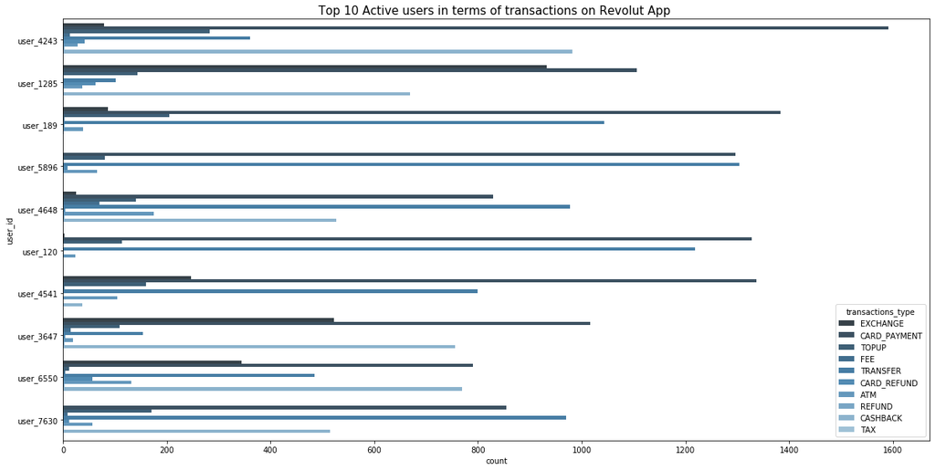

```python
plt.figure(figsize =(20,10))
plt.title("Top 10 Active users in terms of transactions on Revolut App ", fontsize = 15)
import seaborn as sns
sns.countplot(y="user_id", hue="transactions_type", data=classifiers, palette="Blues_d",
              order=classifiers.user_id.value_counts().iloc[:10].index)
```

As evidenced by the plot above, user 4243 is the top user of the App in terms of transactions spanning 310 days, 21 hours and 58 minutes

**ENGAGED AND UNENGAGED USERS**

For this classifier model, there are 1370285 unique transactions in the data and 5493 unique app users. Split equally, it should be 249 transactions per user in 310 days. That is 0.8 transactions per day

For this project, the engaged user is defined as a user with more than or equals to 249 transactions in the space of 310 days and an unengaged user is defined as a user with less than 249 transactions in the same amount of days

```python
series = classifiers.user_id
classifiers['count'] = series.groupby(series).transform('count') #count the number of transactions per user
classifiers.loc[classifiers['count'] >= 249, 'engagement'] = 1 #seperating the class for engaged user
classifiers.loc[classifiers['count'] < 249, 'engagement'] = 0 #seperating the class for unengaged user
```

```python
values = classifiers.groupby('user_id')['engagement'].value_counts() #group the values by user_id and engagement values 1 or 0
new_users = pd.DataFrame(values)
new_users.drop(columns = ['engagement'], inplace = True)
new_users.reset_index(inplace=True)
amount_usd= classifiers.groupby('user_id')['amount_usd'].sum() #calculates the total transactional amount per user
amount  = pd.DataFrame(amount_usd)
amount.reset_index(inplace=True)
```

```python
series = notify.user_id
notify['notify_count'] = series.groupby(series).transform('count') #count the number of notifications per user
notify_values = notify.groupby('user_id')['notify_count'].value_counts()
notifications = pd.DataFrame(notify_values) #create a datframe that groups each user by number of notifications
notifications.drop(columns = ['notify_count'], inplace = True)
notifications.reset_index(inplace=True)
```

**MERGING ALL THE DATFRAMES INTO ONE FOR THE CLASSIFICATION MODELLING**

```python
eng_amount = pd.merge(amount, new_users, how = 'inner' , on = "user_id")
notify_amount = pd.merge(eng_amount, notifications, how = 'inner', on ='user_id') #note that not every user recieve notifications
device_notify = pd.merge(notify_amount, devices, how ='inner', on = 'user_id')
users_table = pd.merge(device_notify, users, how = 'inner', on= 'user_id')
users_table.head() #finalised data on all users to be used for the classified model
```

|  | user_id | amount_usd | engagement | notify_count | brand | birth_year | country | city | created_date | user_settings_crypto_unlocked | plan | attributes_notifications_marketing_push | attributes_notifications_marketing_email | num_contacts | num_referrals | num_successful_referrals |
| --- | --- | --- | --- | --- | --- | --- | --- | --- | --- | --- | --- | --- | --- | --- | --- | --- |
| 0 | user_0 | 13683.77 | 1.0 | 8 | Apple | 1989 | PL | Gdansk | 2018-01-13 05:15:15.599466 | 1 | STANDARD | 1.0 | 1.0 | 3 | 0 | 0 |
| 1 | user_1 | 6103.88 | 0.0 | 7 | Apple | 1975 | GB | London | 2018-01-29 03:38:46.676876 | 0 | STANDARD | NaN | NaN | 21 | 0 | 0 |
| 2 | user_10 | 52149.94 | 1.0 | 6 | Apple | 1980 | FR | Paris | 2018-01-04 08:05:15.466282 | 0 | STANDARD | 1.0 | 1.0 | 38 | 0 | 0 |
| 3 | user_100 | 20777.82 | 0.0 | 4 | Apple | 1969 | GB | St Clement Jersey | 2018-01-15 08:42:17.099386 | 0 | STANDARD | NaN | NaN | 0 | 0 | 0 |
| 4 | user_1002 | 28938.87 | 1.0 | 11 | Android | 1976 | LT | Zalesa | 2018-01-13 01:04:25.771157 | 0 | STANDARD | NaN | NaN | 14 | 0 | 0 |

# QUESTION 3

# MACHINE LEARNING CLASSIFIER MODELLING

The first step in this process is to build a logistic regression model, one of the more basic classifiers to classify the target variable Engagement with 1 being an engaged user and 0 being an unengaged user.

There are also classifier model evaluation metrics such as Precision, Recall, Accuracy and obviously determining the optimal precision-recall trade-off for a given classifier- Reciever operating characteristic(ROC) curves and the AUC(area under the curve).

```python
users_table.head() #this dataset contains the information about the detremined metric and the key features that might be able to predict the enagaged and unengaged users.
```

|  | user_id | amount_usd | engagement | notify_count | brand | birth_year | country | city | created_date | user_settings_crypto_unlocked | plan | attributes_notifications_marketing_push | attributes_notifications_marketing_email | num_contacts | num_referrals | num_successful_referrals |
| --- | --- | --- | --- | --- | --- | --- | --- | --- | --- | --- | --- | --- | --- | --- | --- | --- |
| 0 | user_0 | 13683.77 | 1.0 | 8 | Apple | 1989 | PL | Gdansk | 2018-01-13 05:15:15.599466 | 1 | STANDARD | 1.0 | 1.0 | 3 | 0 | 0 |
| 1 | user_1 | 6103.88 | 0.0 | 7 | Apple | 1975 | GB | London | 2018-01-29 03:38:46.676876 | 0 | STANDARD | NaN | NaN | 21 | 0 | 0 |
| 2 | user_10 | 52149.94 | 1.0 | 6 | Apple | 1980 | FR | Paris | 2018-01-04 08:05:15.466282 | 0 | STANDARD | 1.0 | 1.0 | 38 | 0 | 0 |
| 3 | user_100 | 20777.82 | 0.0 | 4 | Apple | 1969 | GB | St Clement Jersey | 2018-01-15 08:42:17.099386 | 0 | STANDARD | NaN | NaN | 0 | 0 | 0 |
| 4 | user_1002 | 28938.87 | 1.0 | 11 | Android | 1976 | LT | Zalesa | 2018-01-13 01:04:25.771157 | 0 | STANDARD | NaN | NaN | 14 | 0 | 0 |

```python
users_table.engagement = users_table.engagement.astype(int) #convert float values to integer values
users_table.engagement.value_counts() #this tells us we have 3780 unengaged users and 1650 engaged users(already this points out a notion of class imabalance)
users_table.info() #all except the attributes notification columns have non-null values
```

```
<class 'pandas.core.frame.DataFrame'>
Int64Index: 5430 entries, 0 to 5429
Data columns (total 16 columns):
user_id                                     5430 non-null object
amount_usd                                  5430 non-null float64
engagement                                  5430 non-null int64
notify_count                                5430 non-null int64
brand                                       5430 non-null object
birth_year                                  5430 non-null int64
country                                     5430 non-null object
city                                        5430 non-null object
created_date                                5430 non-null object
user_settings_crypto_unlocked               5430 non-null int64
plan                                        5430 non-null object
attributes_notifications_marketing_push     3564 non-null float64
attributes_notifications_marketing_email    3564 non-null float64
num_contacts                                5430 non-null int64
num_referrals                               5430 non-null int64
num_successful_referrals                    5430 non-null int64
dtypes: float64(3), int64(7), object(6)
memory usage: 721.2+ KB
```

Note that email and push notifications still have null values, since these are categorical variables we can't just impute, they won't feature in the model

**RUNNING A BASELINE LOGISTIC REGRESSION MODEL**

*DUMMY THE CATEGORICAL VARAIBLES AND SORT OUT PREDICTORS AND TARGET VARAIBLES*

```python
predictor_var  = ['country','brand', 'birth_year', 'plan', 'user_settings_crypto_unlocked','notify_count','amount_usd','num_contacts']
predictors= pd.get_dummies(users_table[predictor_var], drop_first = True)
target = users_table['engagement']
```

```python
predictors.head()
```

|  | birth_year | user_settings_crypto_unlocked | notify_count | amount_usd | num_contacts | country_BE | country_BG | country_CH | country_CY | country_CZ | country_DE | country_DK | country_EE | country_ES | country_FI | country_FR | country_GB | country_GI | country_GR | country_HR | country_HU | country_IE | country_IS | country_IT | country_LI | country_LT | country_LU | country_LV | country_MT | … |
| --- | --- | --- | --- | --- | --- | --- | --- | --- | --- | --- | --- | --- | --- | --- | --- | --- | --- | --- | --- | --- | --- | --- | --- | --- | --- | --- | --- | --- | --- | --- |
| 0 | 1989 | 1 | 8 | 13683.77 | 3 | 0 | 0 | 0 | 0 | 0 | 0 | 0 | 0 | 0 | 0 | 0 | 0 | 0 | 0 | 0 | 0 | 0 | 0 | 0 | 0 | 0 | 0 | 0 | 0 | … |
| 1 | 1975 | 0 | 7 | 6103.88 | 21 | 0 | 0 | 0 | 0 | 0 | 0 | 0 | 0 | 0 | 0 | 0 | 1 | 0 | 0 | 0 | 0 | 0 | 0 | 0 | 0 | 0 | 0 | 0 | 0 | … |
| 2 | 1980 | 0 | 6 | 52149.94 | 38 | 0 | 0 | 0 | 0 | 0 | 0 | 0 | 0 | 0 | 0 | 1 | 0 | 0 | 0 | 0 | 0 | 0 | 0 | 0 | 0 | 0 | 0 | 0 | 0 | … |
| 3 | 1969 | 0 | 4 | 20777.82 | 0 | 0 | 0 | 0 | 0 | 0 | 0 | 0 | 0 | 0 | 0 | 0 | 1 | 0 | 0 | 0 | 0 | 0 | 0 | 0 | 0 | 0 | 0 | 0 | 0 | … |
| 4 | 1976 | 0 | 11 | 28938.87 | 14 | 0 | 0 | 0 | 0 | 0 | 0 | 0 | 0 | 0 | 0 | 0 | 0 | 0 | 0 | 0 | 0 | 0 | 0 | 0 | 0 | 1 | 0 | 0 | 0 | … |

*NORMALISATION OF THE VARAIBLES BECAUSE FEATURES ARE ON DIFFERENT SCALES AS SOME FEATURES MIGHT IMPACT THE MODEL MORE HEAVILY THAN OTHERS*

```python
scaler = StandardScaler()
scaled_predictors  = scaler.fit_transform(predictors) #scale the predictor varaibles using MinMax Scaler
```

```python
X_train, X_test, y_train, y_test  = train_test_split(scaled_predictors, target, random_state = 12, test_size = 0.3) # instantiate train test split and set test size to be 30% of data
```

```python
y_test.value_counts()
```

```
0    1145
1     484
Name: engagement, dtype: int64
```

```python
y_train.value_counts()
```

```
0    2635
1    1166
Name: engagement, dtype: int64
```

**FIITING THE BASELINE MODEL**

```python
logreg  = LogisticRegression(fit_intercept= False, C = 1e25, solver = 'liblinear', class_weight=None)
model_log = logreg.fit(X_train, y_train)
model_log
```

```python
 y_hat_test = logreg.predict(X_test)
 y_hat_train = logreg.predict(X_train)
```

The next step is to make use of the confusion matrix to check for the True Positives and the True Negatives of the predicted classes.

```python
# Print confusion matrix
cnf_matrix = confusion_matrix(y_test,y_hat_test)
print('Confusion Matrix:\n', cnf_matrix)
```

[output not shown]

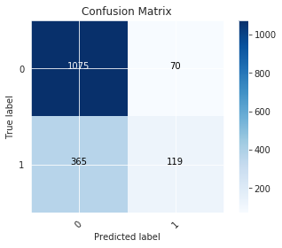

```python
confusion(cnf_matrix, target)
```

**EVALUATION METRICS FOR THE MODEL PERFORMANCE**

```python
print('Training Precision: ', precision_score(y_train, y_hat_train))
print('Testing Precision: ', precision_score(y_test, y_hat_test))
print('\n')

print('Training Recall: ', recall_score(y_train, y_hat_train))
print('Testing Recall: ', recall_score(y_test, y_hat_test))
print('\n')

print('Training Accuracy: ', accuracy_score(y_train, y_hat_train))
print('Testing Accuracy: ', accuracy_score(y_test, y_hat_test))
print('\n')

print('Training F1-Score: ', f1_score(y_train, y_hat_train))
print('Testing F1-Score: ', f1_score(y_test, y_hat_test))
```

[output not shown]

**MODEL ANALYSIS**

The logistic regression model is able to predict the True negative class quite well(1075 cases out of 1145), this might be attributed to the class imbalance in the dataset and it is evident that it did not train well on the positive class as there is a lot of False Negative cases and 119 True positive cases.

**ROC CURVE**

```python
y_score = logreg.fit(X_train, y_train).decision_function(X_test)

fpr, tpr, thresholds = roc_curve(y_test, y_score)
print('AUC: {}'.format(auc(fpr, tpr))) #AUC Value of 0.686-----better than a random model with an AUC of 0.5
```

```
AUC: 0.6863004799884515
```

**ROC CURVE PLOT**

```
AUC: 0.6863004799884515
```

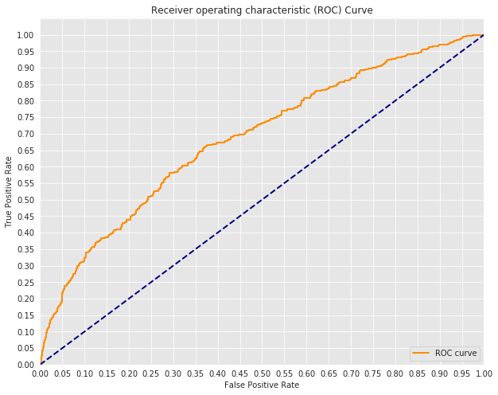

```python
# Seaborn's beautiful styling
sns.set_style('darkgrid', {'axes.facecolor': '0.9'})

print('AUC: {}'.format(auc(fpr, tpr)))
plt.figure(figsize=(10, 8))
lw = 2
plt.plot(fpr, tpr, color='darkorange',
         lw=lw, label='ROC curve')
plt.plot([0, 1], [0, 1], color='navy', lw=lw, linestyle='--')
plt.xlim([0.0, 1.0])
plt.ylim([0.0, 1.05])
plt.yticks([i/20.0 for i in range(21)])
plt.xticks([i/20.0 for i in range(21)])
plt.xlabel('False Positive Rate')
plt.ylabel('True Positive Rate')
plt.title('Receiver operating characteristic (ROC) Curve')
plt.legend(loc='lower right')
plt.show()
```

**So far so good, what this plot means is that the classifier will achieve a true positive rate of 0.65 with a fasle positive rate of 0.35. In this scenario, it performs better than a random classifier**

**CLASS IMBALANCE**

```python
print('Normalized counts: \n')
print(users_table['engagement'].value_counts(normalize=True)) #About 70% of the data is attributed to unengaged users and 30% to engaged users
```

[output not shown]

*USING CLASS WEIGHTS TO CHECK AGAINST CLASS IMBALANCE*

```
LogisticRegression(C=1e+20, class_weight=None, dual=False, fit_intercept=False,
                   intercept_scaling=1, l1_ratio=None, max_iter=100,
                   multi_class='auto', n_jobs=None, penalty='l2',
                   random_state=None, solver='liblinear', tol=0.0001, verbose=0,
                   warm_start=False)
AUC for None: 0.6863004799884515
-------------------------------------------------------------------------------------
LogisticRegression(C=1e+20, class_weight='balanced', dual=False,
                   fit_intercept=False, intercept_scaling=1, l1_ratio=None,
                   max_iter=100, multi_class='auto', n_jobs=None, penalty='l2',
                   random_state=None, solver='liblinear', tol=0.0001, verbose=0,
                   warm_start=False)
AUC for Balanced: 0.6863907033815728
-------------------------------------------------------------------------------------
LogisticRegression(C=1e+20, class_weight={0: 1, 1: 2}, dual=False,
                   fit_intercept=False, intercept_scaling=1, l1_ratio=None,
                   max_iter=100, multi_class='auto', n_jobs=None, penalty='l2',
                   random_state=None, solver='liblinear', tol=0.0001, verbose=0,
                   warm_start=False)
AUC for 2 to 1: 0.6863834855101231
-------------------------------------------------------------------------------------
```

```
LogisticRegression(C=1e+20, class_weight={0: 1, 1: 10}, dual=False,
                   fit_intercept=False, intercept_scaling=1, l1_ratio=None,
                   max_iter=100, multi_class='auto', n_jobs=None, penalty='l2',
                   random_state=None, solver='liblinear', tol=0.0001, verbose=0,
                   warm_start=False)
```

```
AUC for 10 to 1: 0.6871106860586813
-------------------------------------------------------------------------------------
```

```
LogisticRegression(C=1e+20, class_weight={0: 1, 1: 100}, dual=False,
                   fit_intercept=False, intercept_scaling=1, l1_ratio=None,
                   max_iter=100, multi_class='auto', n_jobs=None, penalty='l2',
                   random_state=None, solver='liblinear', tol=0.0001, verbose=0,
                   warm_start=False)
```

```
AUC for 100 to 1: 0.6873560936879713
-------------------------------------------------------------------------------------
```

```
LogisticRegression(C=1e+20, class_weight={0: 1, 1: 1000}, dual=False,
                   fit_intercept=False, intercept_scaling=1, l1_ratio=None,
                   max_iter=100, multi_class='auto', n_jobs=None, penalty='l2',
                   random_state=None, solver='liblinear', tol=0.0001, verbose=0,
                   warm_start=False)
```

```
AUC for 1000 to 1: 0.687329026670035
-------------------------------------------------------------------------------------
```

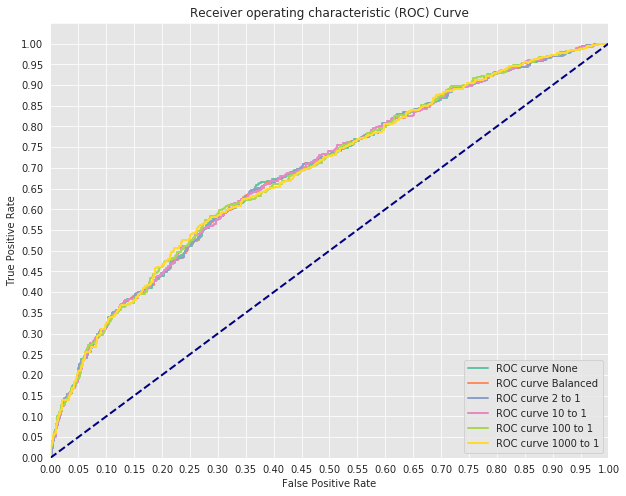

```python
class_imbalance(X_train, X_test, y_train, y_test)
```

As evidenced above with the ROC curve plot, the AUC score sligthly improves with tweaking the class weight but with 0.143% increase when comparing class weights set to none and class weights set to 1000:1.

**USING SMOTE(SYNTHETIC MINORITY OVERSAMPLING) FOR CLASS IMBALANCE**

```
LogisticRegression(C=1e+20, class_weight=None, dual=False, fit_intercept=False,
                   intercept_scaling=1, l1_ratio=None, max_iter=100,
                   multi_class='auto', n_jobs=None, penalty='l2',
                   random_state=None, solver='liblinear', tol=0.0001, verbose=0,
                   warm_start=False)
AUC for 0.1: 0.6863636363636364
-------------------------------------------------------------------------------------
```

```
LogisticRegression(C=1e+20, class_weight=None, dual=False, fit_intercept=False,
                   intercept_scaling=1, l1_ratio=None, max_iter=100,
                   multi_class='auto', n_jobs=None, penalty='l2',
                   random_state=None, solver='liblinear', tol=0.0001, verbose=0,
                   warm_start=False)
AUC for 0.25: 0.6839456494279837
-------------------------------------------------------------------------------------
```

```
LogisticRegression(C=1e+20, class_weight=None, dual=False, fit_intercept=False,
                   intercept_scaling=1, l1_ratio=None, max_iter=100,
                   multi_class='auto', n_jobs=None, penalty='l2',
                   random_state=None, solver='liblinear', tol=0.0001, verbose=0,
                   warm_start=False)
AUC for 0.33: 0.6851853188494714
-------------------------------------------------------------------------------------
```

```
LogisticRegression(C=1e+20, class_weight=None, dual=False, fit_intercept=False,
                   intercept_scaling=1, l1_ratio=None, max_iter=100,
                   multi_class='auto', n_jobs=None, penalty='l2',
                   random_state=None, solver='liblinear', tol=0.0001, verbose=0,
                   warm_start=False)
AUC for 0.5: 0.6881644952903389
-------------------------------------------------------------------------------------
```

```
LogisticRegression(C=1e+20, class_weight=None, dual=False, fit_intercept=False,
                   intercept_scaling=1, l1_ratio=None, max_iter=100,
                   multi_class='auto', n_jobs=None, penalty='l2',
                   random_state=None, solver='liblinear', tol=0.0001, verbose=0,
                   warm_start=False)
AUC for 0.7: 0.6864322061424086
-------------------------------------------------------------------------------------
```

```
LogisticRegression(C=1e+20, class_weight=None, dual=False, fit_intercept=False,
                   intercept_scaling=1, l1_ratio=None, max_iter=100,
                   multi_class='auto', n_jobs=None, penalty='l2',
                   random_state=None, solver='liblinear', tol=0.0001, verbose=0,
                   warm_start=False)
AUC for even: 0.6894366451333501
-------------------------------------------------------------------------------------
```

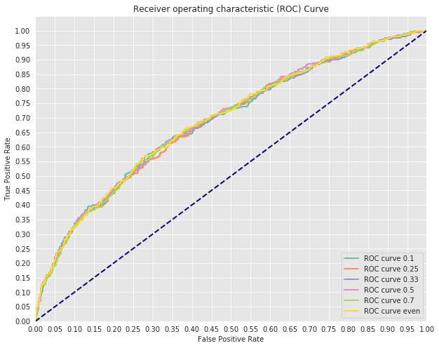

```python
smote_class(X_train, X_test, y_train, y_test)
```

**RANDOM FOREST CLASSIFIER**

```python
#fitting a baseline Random Forest Classifier to the data
forest = RandomForestClassifier(n_estimators =100,max_depth=5)
forest.fit(X_train, y_train)
```

```
RandomForestClassifier(bootstrap=True, ccp_alpha=0.0, class_weight=None,
                       criterion='gini', max_depth=5, max_features='auto',
                       max_leaf_nodes=None, max_samples=None,
                       min_impurity_decrease=0.0, min_impurity_split=None,
                       min_samples_leaf=1, min_samples_split=2,
                       min_weight_fraction_leaf=0.0, n_estimators=100,
                       n_jobs=None, oob_score=False, random_state=None,
                       verbose=0, warm_start=False)
```

**MODEL PERFORMANCE**

```python
#Training accuracy score and test accuracy test
print("The training accuracy score is :", forest.score(X_train, y_train))
print("The test accuracy score is :", forest.score(X_test, y_test)) #the results below indicates the model is not overfitting
```

```
The training accuracy score is : 0.7858458300447251
The test accuracy score is : 0.7790055248618785
```

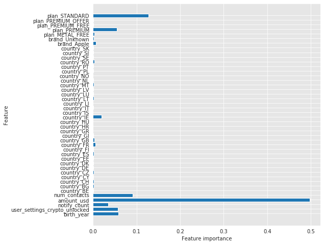

```python
plot_feature_importances(forest) #important features driving the random forest model
```

We can finally see the most important feature driving the model is the amount of transactions in USD per user, other important features are number of contacts on the app, number of notifications, standard and premium plan subscriptions, birth year and also user crypto settings

**USING GRIDSEARCH CV TO INCREASE MODEL PERFORMANCE THROUGH HYPERPARAMETER TUNING**

```python
rf_clf = RandomForestClassifier()
rf_param_grid = {
    'n_estimators': [10, 30, 100, 150, 200],
    'criterion': ['gini', 'entropy'],
    'max_depth': [None, 2, 6, 10, 15],
    'min_samples_split': [5, 10, 15],
    'min_samples_leaf': [3, 6]
}
rf_grid_search = GridSearchCV(rf_clf, rf_param_grid, cv=3)
rf_grid_search.fit(X_train, y_train)
print(f"Training Accuracy: {rf_grid_search.best_score_ :.2%}")
print("")
print(f"Optimal Parameters: {rf_grid_search.best_params_}")
```

```
Training Accuracy: 80.82%

Optimal Parameters: {'criterion': 'entropy', 'max_depth': None, 'min_samples_leaf': 3, 'min_samples_split': 15, 'n_estimators': 30}
```

```python
rf_score = rf_grid_search.score(X_test, y_test)
print('Random forest grid search: ', rf_score) #the accuracy score for the test set for the optimal paramter Random Forest Classifier is 79.9%
```

```
Random forest grid search:  0.7992633517495396
```

```python
rf_train = rf_grid_search.predict(X_train)
rf_test = rf_grid_search.predict(X_test)
# Print confusion matrix
cnf_matrix_1 = confusion_matrix(y_test,rf_test)
print('Confusion Matrix for Optimal Random Forest Classifier:\n', cnf_matrix_1)
```

```
Confusion Matrix for Optimal Random Forest Classifier:
 [[1042  103]
 [ 224  260]]
```

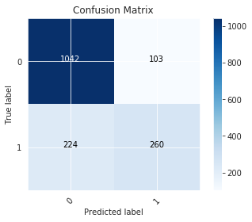

```python
confusion(cnf_matrix_1, target)
```

```python
print('Training Precision: ', precision_score(y_train, rf_train))
print('Testing Precision: ', precision_score(y_test, rf_test))
print('\n\n')

print('Training Recall: ', recall_score(y_train, rf_train))
print('Testing Recall: ', recall_score(y_test, rf_test))
print('\n\n')

print('Training Accuracy: ', accuracy_score(y_train, rf_train))
print('Testing Accuracy: ', accuracy_score(y_test, rf_test))
print('\n\n')

print('Training F1-Score: ', f1_score(y_train, rf_train))
print('Testing F1-Score: ', f1_score(y_test, rf_test))
```

```
Training Precision:  0.8429378531073446
Testing Precision:  0.7162534435261708



Training Recall:  0.6397941680960549
Testing Recall:  0.5371900826446281



Training Accuracy:  0.8529334385687977
Testing Accuracy:  0.7992633517495396



Training F1-Score:  0.727450024378352
Testing F1-Score:  0.6139315230224321
```

The training accuracy for the Random Forest classifier model is 85.2% and the test accuracy is 79.9%

**EXTEREME GRADIENT BOOSTED CLASSIFIER MODEL**

```python
#Run Baseline XGboost classifier model
# Instantiate XGBClassifier
clf = XGBClassifier()

# Fit XGBClassifier
clf.fit(X_train, y_train)

# Predict on training and test sets
training_preds = clf.predict(X_train)
test_preds = clf.predict(X_test)

# Accuracy of training and test sets
training_accuracy = accuracy_score(y_train, training_preds)
test_accuracy = accuracy_score(y_test, test_preds)

print('Training Accuracy: {:.4}%'.format(training_accuracy * 100))
print('Validation accuracy: {:.4}%'.format(test_accuracy * 100))
```

```
Training Accuracy: 83.79%
Validation accuracy: 82.01%
```

The result of the baseline extreme gradient boosted classifier shows a marked improvement compared to the result of the random forest classifier and also shows no sign of overfitting the training data with training accuracy = 83.79% and validation accuracy = 82.01%

**FEATURE IMPORTANCE PLOT FOR THE XGB CLASSIFER**

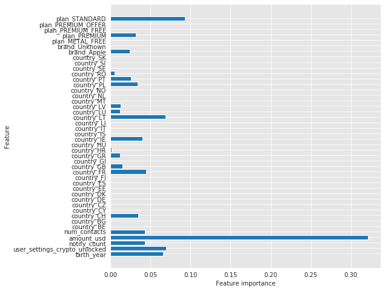

```python
plot_feature_importances(clf) #features driving the gradient boosted model
```

As evidenced from the plot, the extreme gradient boosted classifier is able to find more interactions in the features compared to the random forest classifier, most notably in the country feature column

**TUNING THE XGBOOST CLASSIFIER**

```python
param_grid = {
    'learning_rate': [0.1, 0.2],
    'max_depth': [3, 6, 10],
    'min_child_weight': [1, 2, 5],
    'subsample': [0.3,0.5, 0.7],
    'n_estimators': [50,100,200],
}
grid_clf = GridSearchCV(clf, param_grid, scoring='accuracy', cv=3, n_jobs=1)
grid_clf.fit(X_train, y_train)

best_parameters = grid_clf.best_params_

print('Grid Search found the following optimal parameters: ')
for param_name in sorted(best_parameters.keys()):
    print('%s: %r' % (param_name, best_parameters[param_name]))

training_preds = grid_clf.predict(X_train)
test_preds = grid_clf.predict(X_test)
training_accuracy = accuracy_score(y_train, training_preds)
test_accuracy = accuracy_score(y_test, test_preds)

print('')
print('Training Accuracy: {:.4}%'.format(training_accuracy * 100))
print('Validation accuracy: {:.4}%'.format(test_accuracy * 100))
```

```
Grid Search found the following optimal parameters:
learning_rate: 0.1
max_depth: 3
min_child_weight: 1
n_estimators: 50
subsample: 0.3

Training Accuracy: 82.48%
Validation accuracy: 81.65%
```

**CONFUSION MATRIX FOR THE XGB CLASSIFIER MODEL**

```python
cnf_matrix_2 = confusion_matrix(y_test,test_preds)
print('Confusion Matrix for Optimal Gradient Boosted Classifier:\n', cnf_matrix_2)
```

```
Confusion Matrix for Optimal Gradient Boosted Classifier:
 [[1019  126]
 [ 173  311]]
```

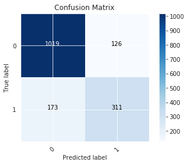

```python
confusion(cnf_matrix_2, target)
```

```python
print('Training Precision: ', precision_score(y_train, training_preds))
print('Testing Precision: ', precision_score(y_test, test_preds))
print('\n\n')

print('Training Recall: ', recall_score(y_train, training_preds))
print('Testing Recall: ', recall_score(y_test, test_preds))
print('\n\n')

print('Training Accuracy: ', accuracy_score(y_train, training_preds))
print('Testing Accuracy: ', accuracy_score(y_test, test_preds))
print('\n\n')

print('Training F1-Score: ', f1_score(y_train, training_preds))
print('Testing F1-Score: ', f1_score(y_test, test_preds))
```

```
Training Precision:  0.7293577981651376
Testing Precision:  0.7116704805491991



Training Recall:  0.6818181818181818
Testing Recall:  0.6425619834710744



Training Accuracy:  0.824782951854775
Testing Accuracy:  0.8164518109269491



Training F1-Score:  0.7047872340425531
Testing F1-Score:  0.6753528773072748
```

# QUESTION 4

# Let’s assume an unengaged user is a churned user. Now suppose we use your model to identify unengaged users and implement some business actions try to convert them to engaged users (commonly known as reducing churn)

How would you set up a test/experiment to check whether we are actually reducing churn?

I would run an A/B testing experiment to check if the business actions implemented is actually reducing churned users.

- One version would be the app without the business actions implemented to reduce churned users.
- The other version would be the app with the business actions implemented to reduce churned users.

The steps taken in designing an A/B test are:

- Choosing a Metric
- Defining null and Alternative Hypothesis hypothesis: Ho and Ha
- Investigating alpha, power ,effect size and sample size

Assuming version 1 app is the app with no business actions implemented and version 2 app is the app with business actions implemented. In this scenario: Null Hypothesis Ho: There is no difference in the number of transactions between churned users on app version 1 and app version 2. Alternative Hypothesis: Number of transactions for churned users on app version 2 is greater than the number of transactions for churned users on app version 1.

There are also other factors not part of the data that can be used for metric to check customer enagagment such as:

- Number of logins on the app
- Time spent online on the app
- Number of features clicked on per login on the app

The metrics and techniques that I would use to assess the impact of the business actions includes: P-value of the test experiment- If the P-value is less than the alpha threshold set for the experiment that means the we can reject the null hypothesis and conclude the difference in the experiments is statistically significant. Note that alpha is the marginal threshold at which you are okay rejecting the null hypothesis and accepting the alternative hypothesis,also this doesn't prove that there is a direct relationship between the dependent and independent variables--just that we have enough evidence to the contrary to show that we can no longer believe that there is no relationship between them.

p-value is the probability of observing a test statistic at least as large as the one observed, by random chance, assuming that the null hypothesis is true.

Practical Signifcance tells us more about the tests/experiment we run, what is the size of the difference between the two groups used in our experiment? Effect size is used to quantify the size of the difference between two groups under observation and allows us to answer---- *How well does it work in a range of contexts?'.* Cohen’s d is one of the most common ways to measure effect size. As an effect size, Cohen's d is typically used to represent the magnitude of differences between two (or more) groups on a given variable, with larger values representing a greater differentiation between the two groups on that variable.

# FINAL DATA FILE

```python
users_table.to_csv("final_data.csv", encoding='utf8')
```